# Phenoarch platform - Cleaning procedure - Curve level - CARBayesST library

I.Sanchez

novembre 14, 2019

# 1 Objective

Detection of outliers in time courses of an experiment in PhenoArch greenhouse. In this vignette, we use a toy data set of the *phisStatR* library (anonymized real data set).

Please, have a look on the names of the columns of the input data set. The function is not generic and needs specific columns names in the input data set:

- Line: the x-coordinate in the lattice (numeric)
- Position: the y-coordinate in the lattice (numeric)
- Ref: a unique identifiant by pot, repetition and alias
- scenario: the scenario applied to the experiment
- genotypeAlias: the used genotypes in the experiment

The example is conducted on plantHeight parameter, we modelise the plantHeight taking into account the temporality (thermal time) and the spatiality (lattice structure) with a bayesian spatio-temporal ANOVA model [3].

To detect outlier points, we retrieve the standardised residuals computed by the model and a point is an outlier if abs(res) > *threshold* (here threshold==4). the user will be able to change this threshold.

We produced the output of the model as well as some graphics.

# 2 Import of data

The input dataset must contain some predefined columns, have a look to the structure of *mydata*:

```r
  library(lubridate)
  library(dplyr)
  library(phisStatR)

  myReport<-substr(now(),1,10)

  mydata<-plant1
  str(mydata)
```

```
## 'data.frame':    47022 obs. of  14 variables:
##  $ Ref            : Factor w/ 1680 levels "manip1_10_10_WW",..: 131 131 131 131 131 131 131 131 131 131 ...
##  $ experimentAlias: Factor w/ 1 level "manip1": 1 1 1 1 1 1 1 1 1 1 ...
##  $ Day            : Factor w/ 42 levels "2013-02-01","2013-02-02",..: 3 4 5 6 7 9 9 10 11 12 ...
##  $ potAlias       : int  1 1 1 1 1 1 1 1 1 1 ...
##  $ scenario       : Factor w/ 2 levels "WD","WW": 2 2 2 2 2 2 2 2 2 2 ...
##  $ genotypeAlias  : Factor w/ 274 levels "11430_H","A310_H",..: 165 165 165 165 165 165 165 165 165 165 ...
##  $ repetition     : int  1 1 1 1 1 1 1 1 1 1 ...
##  $ Line           : int  1 1 1 1 1 1 1 1 1 1 ...
##  $ Position       : int  1 1 1 1 1 1 1 1 1 1 ...
##  $ thermalTime    : num  1.29 2.65 3.98 5.32 6.66 ...
##  $ plantHeight    : num  140 151 213 239 271 ...
##  $ leafArea       : num  0.018 0.019 0.0208 0.0222 0.0235 ...
##  $ biovolume      : num  0.253 0.62 1.201 1.68 3.396 ...
##  $ Repsce         : Factor w/ 15 levels "1_WD","1_WW",..: 2 2 2 2 2 2 2 2 2 2 ...
```

# 3 CARBayesST library

A bayesian approach to model these data where the spatio-temporal structure is modelled via sets of autocorrelated random effets. Conditional autoregressive (CAR) priors and spatio-temporal extensions thereof are typically assigned to these random effects to capture the autocorrelation, which are special cases of a Gaussian Markov random Filed (GMRF) [3].

*ST.CARanova()* decomposes the spatio-temporal variation into 3 components:

- an overall spatial effect common to all time periods
- an overall temporal trend common to all spatial units
- a set of independent space-time interactions

we can add others factors (here the scenario (quali) …)

The spatio-temporal auto-correlation is modelled by a common set of spatial random effect and a common set of temporal random effects and both are modelled by the CAR prior (Conditional AutoRegressive).

**Description of the results’s table**:

- **Median**: posterior median estimation
- **2.5 and 97.5%**: 95% credible interval
- **Geweke.diag**: the convergence diagnostic implemented in the **coda** package. takes form of a Z-score, so the convergence is suggested by the statistic being **within** the range (-1.96; 1.96)

**Model fit criteria**

- DIC: deviance information criterion
- p.d: its corresponding estimated effective number of parameters
- WAIC: the Watanabe-Akaike information criterion
- p.w: its corresponding estimated number of effective parameters
- LMPL: the log marginal predictive likelihood

In model’s comparison, the best fitting model is the one that minimises the DIC and WAIC but maximises the LMPL.

**As the bayesian model can take a while, in this example, we initialise burnin=10 and n.sample=110 - not enough in real analysis!**

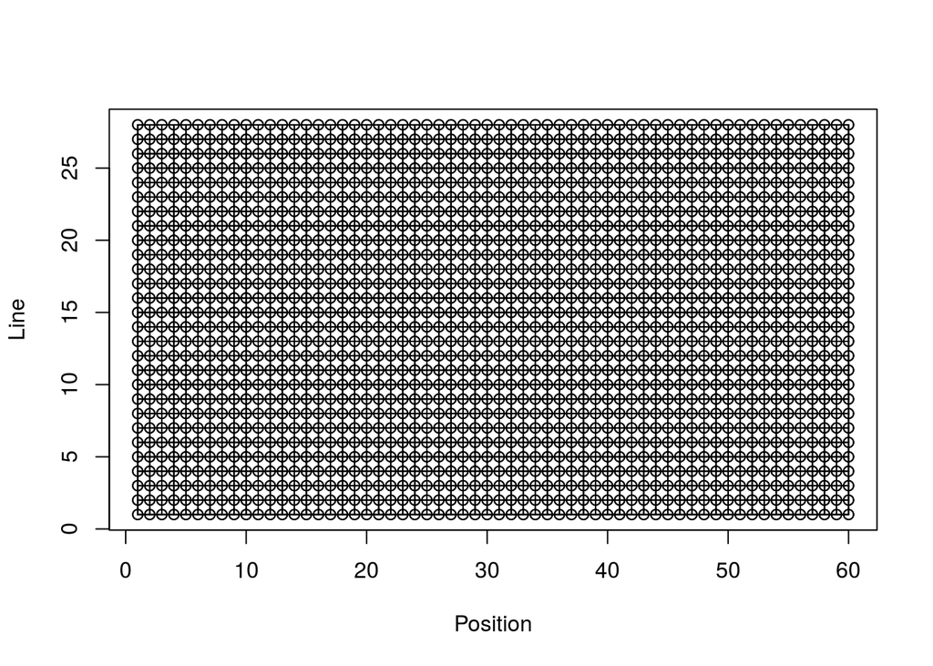

```
## Setting up the model.
## Generating 100 post burnin and thinned (if requested) samples.
##
## Summarising results.
## Finished in  163.2 seconds.
##            used  (Mb) gc trigger   (Mb) max used  (Mb)
## Ncells  2963350 158.3    5515424  294.6  2963350 158.3
## Vcells 66893827 510.4  214781256 1638.7 66893827 510.4
```

```r
  # We suppress observations with missing data in time variable (here thermalTime)
  mydata<-filter(mydata,!is.na(mydata$thermalTime))
  model<-fitCARBayesST(datain=mydata,xvar="thermalTime",trait="plantHeight",k=2,
          graphDist=TRUE,burnin=10,n.sample=110,
          formulaModel=as.formula(plantHeight~scenario+genotypeAlias),typeModel="anova",verbose=TRUE)
```

```r
  # print the result of the bayesian modelling
  printCARBayesST(modelin=model[[1]])
```

```
##                              Median      2.5%      97.5% Geweke.diag
## (Intercept)                806.2463  776.3871   821.9632        -8.4
## scenarioWW                  -4.0981   -7.5837    -1.6059        -2.0
## genotypeAliasA310_H        -53.9022  -87.5047   -31.6301        -1.5
## genotypeAliasA347         -304.7737 -334.3931  -271.0169         3.0
## genotypeAliasA347_H         -0.8057  -39.4563    27.1392         3.6
## genotypeAliasA374_H         36.8113   11.2386    65.6553         1.2
## genotypeAliasA375_H         60.4063   38.1941    87.4178         0.7
## genotypeAliasA3_H           79.8473   47.0501   102.7766         0.3
## genotypeAliasA554_H        -99.2978 -116.2514   -44.9770         2.9
## genotypeAliasAS5707_H       19.3879   -3.4499    44.0695         2.1
## genotypeAliasB100_H         14.3464   -8.6479    72.0730         3.5
## genotypeAliasB104_H        -35.7136  -69.6221   -14.5321         0.7
## genotypeAliasB105_H        -52.2359  -77.3884   -22.7938         0.4
## genotypeAliasB106_H         42.4992    0.0385    84.0746        -1.0
## genotypeAliasB107_H        -64.3780  -94.0484   -26.5748        -1.7
## genotypeAliasB108_H          5.7333  -31.9442    27.6460         2.9
## genotypeAliasB109_H          2.9919  -18.9162    44.3538         1.9
## genotypeAliasB110_H        -49.8731  -80.9709     2.6456         2.2
## genotypeAliasB113_H          2.2894  -27.6662    32.4214        -0.5
## genotypeAliasB14a_H        -93.8059 -117.2882   -75.1028         6.7
## genotypeAliasB37_H         -66.8377 -103.7999   -44.8717         2.3
## genotypeAliasB73          -169.7255 -202.5657  -123.3847         3.0
## genotypeAliasB73_H          13.7188  -20.0319    44.9052        -0.3
## genotypeAliasB73_SILK      -25.9450  -49.0489     2.9542         5.0
## genotypeAliasB84_H          -2.0056  -35.7321    35.7082         2.1
## genotypeAliasB89_H         -62.0634  -94.1974   -24.5991         8.9
## genotypeAliasB97_H          70.2622   31.6288   114.1527         4.8
## genotypeAliasB98_H         -87.4918 -134.5922   -62.3426         4.4
## genotypeAliasC103_H        -10.6156  -42.1130    21.0901         1.5
## genotypeAliasCO109_H         2.4811  -32.6849    42.2939         4.1
## genotypeAliasCR1Ht_H        -2.7277  -67.9913    20.9292         0.3
## genotypeAliasD09_H          15.2980  -22.7933    48.1107       -10.7
## genotypeAliasDE811_H       -49.7149 -100.5872    -4.8798        -2.6
## genotypeAliasDK2MA22_H     103.7023   75.1770   122.9395        -0.8
## genotypeAliasDK4676A_H     -16.0165  -36.2474     5.8523        -0.8
## genotypeAliasDK78010_H     -66.3425 -101.8254   -41.9445        -0.3
## genotypeAliasDK78371A_H     -0.1585  -39.3931    31.7676        -0.2
## genotypeAliasDKFAPW_H      -52.0598 -101.2991   -16.8242         2.9
## genotypeAliasDKFBHJ_H       52.9971   20.4006    83.3094        -7.1
```

[output cut: 230 more lines]

```
## genotypeAliasW9           -506.1417 -536.5311  -461.5745         3.3
## genotypeAliasW95115_H       41.5730    8.4339    64.9183        -3.4
## genotypeAliasW9_H          -59.2875  -82.2761   -18.6352         7.4
## genotypeAliasWf9_H         127.7572  105.8166   175.3110         0.9
## genotypeAliasX061_H         49.2583   21.9034   107.5434         9.8
## genotypeAliasX697_H         -1.6806  -41.1033    27.9536        -4.7
## tau2.S                    4776.1467 3124.3928  5429.6919        -4.1
## tau2.T                   25901.5865 3600.4050 57302.8163         6.1
## nu2                       6322.0267 6203.5644  9600.9780         2.5
## rho.S                        0.4795    0.3652     0.5932       -13.5
## rho.T                        0.7897    0.5462     0.9962        -6.1
##           DIC           p.d          WAIC           p.w          LMPL
##    497032.192      2215.472    504435.904      6795.463   -249803.497
## loglikelihood
##   -246300.624
```

```r
  outtmp<-outlierCARBayesST(modelin=model[[1]],datain=model[[2]],threshold=4,trait="plantHeight")
```

[figure not shown]

## 3.1 Outlier detection

The output report can be over-sized (more than 1Mb), for size of sub-directories in packages purposes, I choose to represent only the first genotypes…

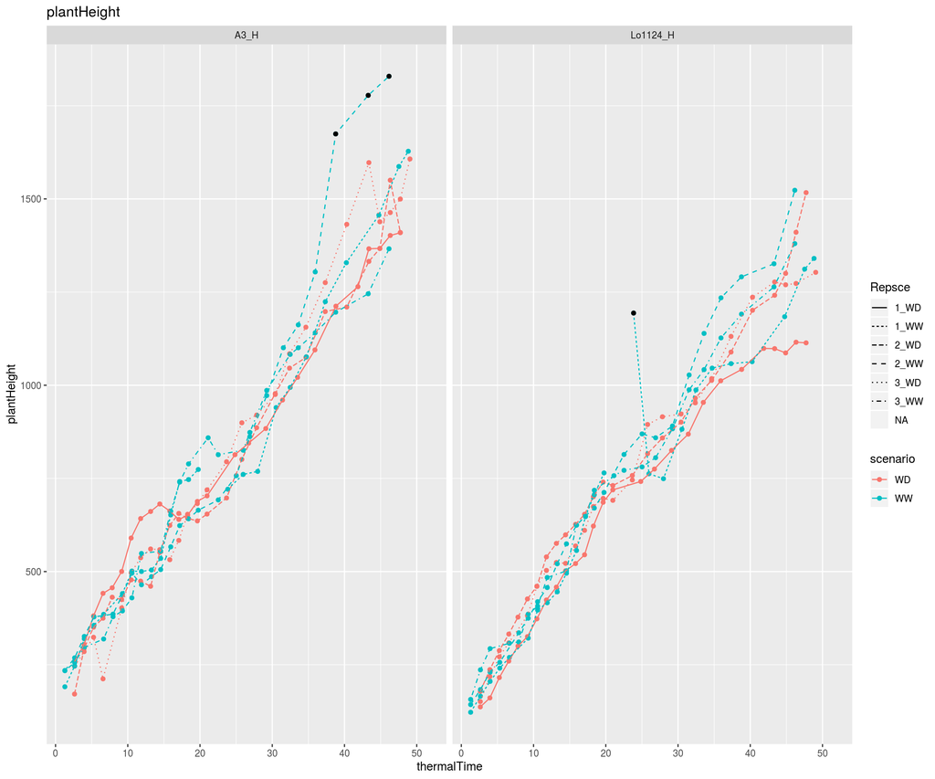

```r
  mygeno<-as.character(unique(model[[2]][,"genotypeAlias"]))
  mygeno<-mygeno[1:6]
  for (i in seq(1,length(mygeno),by=15)){
      myvec<-seq(i,i+14,1)
      plotCARBayesST(datain=model[[2]],outlierin=outtmp,myselect=myvec,trait="plantHeight",xvar="thermalTime")
  }
```

# 5 References

1. R Development Core Team (2015). R: A language and environment for statistical computing. R Foundation for Statistical Computing, Vienna, Austria. ISBN 3-900051-07-0, URL http://www.R-project.org.
2. Roger S. Bivand, Edzer Pebesma, Virgilio Gomez-Rubio, 2013. Applied spatial data analysis with R, Second edition. Springer, NY. http://www.asdar-book.org/
3. Duncan Lee, Alastair Rushworth and Gary Napier (2017). CARBayesST: Spatio-Temporal Generalised Linear Mixed Models for Areal Unit Data. R package version 2.5. https://CRAN.R-project.org/package=CARBayesST